# AdvGIS | Ice Breaker Challenge

Center for Geospatial Analysis

2021

## NWS Alert

THIS IS A NATIONAL ALERT!

`-------------------------`

THE WORLD WILDLIFE FOUNDATION REPORTS THAT SIX OF ITS PERSONNEL ARE TRAPPED IN THE WILDFIRES OF CALIFORNIA. THEY HAVE GPS-ENABLED RADIOS AND REQUIRE IMMEDIATE ASSISTANCE FINDING THE DISTANCE AND DIRECTION TO THE NEAREST SAFE HAVEN FOR RESCUE.

***

THE UNITED STATES GEOLOGICAL SURVEY REPORTS THAT MAUNA LOA VOLCANO IS UNDER A LEVEL 4 ERUPTION WARNING. COINCIDENTALLY, LAWRENCE NATIONAL LABORATORIES HAVE RAISED THE TSUNAMI WARNING LEVEL BASED ON THEIR FIBER OPTIC OCEAN FLOOR SENSOR NETWORK. THE GOVERNOR OF HAWAII IS ASKING FOR IMMEDIATE ASSISTANCE FOR EVACUATION ZONE RECOMMENDATIONS.

***

THE DEADLINE FOR DELIVERABLES IS ASAP.

## Deliverables

### Instructions

To tackle these two problems, the class will be divided into two teams: **Red Team** and **Blue Team**. Each team is assigned to solve one of the two real-world problems (see the corresponding tabs at the top of this page). You have approximately two (2) hours to research solutions to your problem.

In general, the rules are:

- You may use any means necessary; this includes all tools and resources you have access to.

  *Your professor does not count towards this rule.*
- You must submit only one deliverable packet (see description below), which must be signed off by all members of your team.
- Each member of your team must be able to explain your solution and, in general, how the answer was decided upon.

  *Work together and keep a complete record of your research, data sources, and processes!*

### The Deliverables Packet

To complete this task, each team should create and submit a single report that includes the following sections.

*You may use Google Docs.*

1. Cover Page
   - cover page should read like a memo
   - include a description of each team members’ roles and/or contributions
   - dated and signed by all team members
   - use the following as a template:

     ```
     TO:      DAVIS, CGA, WILLIAM & MARY, VA
     FROM:    RED/BLUE TEAM (*choose appropriately)
     DATE:    2021-09-02
     SUBJECT: RECOMMENDED ACTIONS

     The following report is accurate and complete to the best of our ability.
     Please find the summary of our findings along with our methods and references
     in the pages attached to this report. We have outlined the contributions from
     each of our group members below. If you have any questions, you may follow up
     with any one of us.


     MEMBER NAME A - Roles:

     __________________
     signature/date


     MEMBER NAME B - Roles:

     __________________
     signature/date
     ```

2. Introduction - *“what you intend to do”*
   - include the problem title
   - include the problem summary
   - include the intended goals
3. Findings - *“your main results”*
   - include succinct answers to the question(s) that were raised
   - support your answers with tables and figures as necessary
4. Methods - *“how you did it”*
   - include any data sources you used
     - note the coordinate reference systems of any GIS data sources you used
     - note spatial resolutions of any raster datasets (*x* and *y* cell sizes)
     - also note other web resources you used
   - include any geoprocessing tools you used
     - summarize what the tool was used to accomplish
     - mention inputs/outputs and any options you selected
   - you may include figures to help demonstrate your methods (e.g., ModelBuilder)
5. Discussion - *“what you learned from what you did”*
   - here you can include what you would have done differently if you had more time or if you had to start all over again
   - leave a blank page to fill in later if you do not have any changes you would make
6. References - *“what you used to get things done”*
   - data sources and any other research you did to complete your project
   - choose a reference style (e.g. APA) and be consistent
   - make certain you cite your references appropriately in the introduction, methods, finding, and/or discussion
7. Appendix (*optional*)
   - you may include files, tables, datasets, etc. on the class USB drive to exemplify the work you did
   - be sure to include a text file that lists the names and paths to your resources with a description of what they are and/or where you got them

## Red Team

### “Find the River”

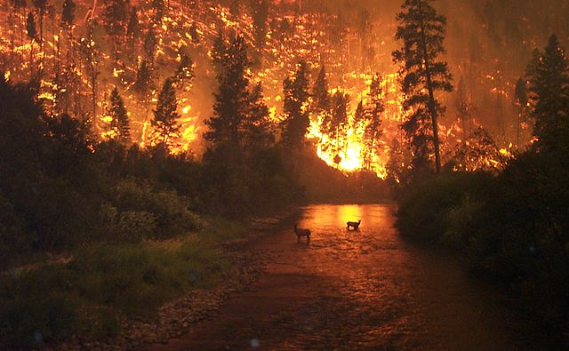

“Elk Bath” (2000) by J. McColgan, Bureau of Land Management, Alaska Fire Service. Online: [Wikipedia](https://upload.wikimedia.org/wikipedia/commons/thumb/d/d4/Deerfire_high_res.jpg/640px-Deerfire_high_res.jpg).

**Intended goals**

- Understand the role of GIS in disaster response
- Exercise data exploration and feature geolocating and projecting
- Utilize distance and direction geoprocessing tools
- Analyze maps to determine specific outcomes

**Problem Statement**

Six people are lost within the Caldor Fire in California as the fast-moving wildfire spreads out in their direction. They are hiking the area’s state and national forests as a part of an animal rescue expedition. Five of the hikers have radioed in their locations (see **Table 1**) and the last known location of the sixth was near Frog Pond just south of Nebelhorn.

The National Aeronautics and Space Agency’s Fire Information for Resource Management System ([FIRMS](https://firms.modaps.eosdis.nasa.gov/)) has been helpful providing data on the latest fires in the area.

You have less than one hour to provide recommendations to the closest haven for each of the six hikers. The hikers have no mode of transportation other than hiking. Assume that all residences and businesses in the area have been evacuated.

You may use whatever information is available to you. This includes GIS data from previous classes and from other web sources. You may use ArcGIS Pro, QGIS, Google Earth, or other web-based mapping service.

**Table 1.** Five of six hiker coordinates.

|  | Latitude (DMS) | Longitude (DMS) |
| --- | --- | --- |
| Hiker 1 | 38° 50’ 45.60" N | 119° 59’ 24.00" W |
| Hiker 2 | 38° 39’ 28.80" N | 120° 39’ 14.40" W |
| Hiker 3 | 38° 36’ 32.40" N | 120° 39’ 0.00" W |
| Hiker 4 | 38° 50’ 24.00" N | 120° 4’ 4.80" W |
| Hiker 5 | 38° 37’ 55.12" N | 120° 12’ 25.12" W |
| Hiker 6 | N/A | N/A |

**Before You Begin**

1. Meet with your team and introduce yourselves
2. Consider what you need
   1. Quickly brainstorm a list of information you think you need to solve this problem.
   2. Examine your list and prioritize each item as either critical or supplemental to addressing this issue.
   3. Starting with your critical items, make a note next to each item of who or where you might be able to get this information from.
3. Identify sources
   1. How can you identify where the six hikers are located on a map?
   2. What might serve as a haven for a hiker in a wildfire?
   3. What might serve as an obstacle for a hiker?
   4. How can you show where fires, obstacles, and havens are located on a map?
   5. What resources did you use to find these answers?
4. Define the space
   1. Where can you find maps of your study area?
   2. What kind of maps do you need?
   3. Based on current maps of the region, what’s there?
   4. Find maps of the current fires in the area. What are you using at “current” (e.g., 24 hours, 48 hours, or 7 days)?
   5. Do your best to draw or create a map that combines the fires and the hikers.
      - Where might some obstacles be located that impede a hiker’s travel?
      - Where might some potential safe havens be located?
      - Based on your map, which hiker appears to be at the greatest risk?
5. Delegate tasks among your team
   - You don’t have a lot of time to come up with your solution.
   - Decide who will be in charge of what tasks.
   - Take advantage of each other’s strengths.
   - Pair up when possible.

**Questions to Answer**

1. Identify potential havens.
   - Come up with a list of locations where your hikers can seek shelter.
2. Identify potential obstructions.
   - Come up with a list of obstacles that hikers may need to avoid and reasoning for each.
3. What geolocation did you give the sixth hiker?
4. Determine the nearest haven for each hiker.

If you have time, please try to answer the following questions.

1. How should each hiker get to their haven?
2. How far and in what direction must they travel? Include an estimate of how long it might take them to get there.
3. What is the maximum elevation change they must travel over?

Include figures in your report

- area map of the locations of all six hikers over a basemap that shows topography
- locations of labeled potential havens proximal to each of the hikers; if possible, overlay your features with potential obstacles
  - for clarity, you may need to separate this into multiple figures

## Blue Team

### “It’s the End of the World as We Know It”

[figure not shown]

“View of the Eruption of Mount Vesuvius 1770’s” (ca. 1794) by Pierre-Jacques Volaire.

**Intended goals**

- Understand the role of GIS in disaster response
- Exercise data exploration and feature geolocating and projecting
- Utilize geoprocessing tools for suitability analysis
- Analyze maps to determine specific outcomes

**Problem Statement**

Hawaii is well known for its vulnerability to natural disasters, such as volcanic eruptions and tsunamis. Recent seismic measurements have indicated that a volcanic eruption is imminent. A gigantic wave further threatens the people living along the coastal regions of the state.

You less than one hour to provide recommendations for suitable locations where people can seek safety from both the volcano and a tsunami.

You may use whatever information is available to you. This includes GIS data from previous classes and from other web sources. You may use ArcGIS Pro, QGIS, Google Earth, or other web-based mapping service.

**Before You Begin**

1. Meet with your team and introduce yourselves.
2. Consider the information you need.
   1. Quickly brainstorm a list of information you think you need to solve this problem.
   2. Examine your list and prioritize each item as either critical or supplemental to addressing this issue.
   3. Starting with your critical items, make a note next to each item of who or where you might be able to get this information from.
3. Identify sources.
   1. Find Mauna Loa volcano’s location.
      - address:
      - coordinates in longitude and latitude:
      - elevation above mean sea level:
      - other location identifiers:
   2. What resources did you use to find these answers?
4. Define the space.
   1. Find maps of the volcano hazard regions of Hawai’i Island and of the tsunami evacuation zones (*Hint: try using the Hawaii Open Data Portal*).
   2. Do your best to draw or create a map that combines both Mauna Loa volcano risk zones and tsunami evacuation zones.
      - Which appears to be the greater risk with respect to impacted area?
      - Is there any overlap between the two risk zones? If so, where?
   3. Estimate the size of your impact areas. Be sure to include units with your answer (for example: acres, hectares, square miles). How did you determine the area?
5. Analyze your impact area
   1. Use an online mapping service—e.g., Apple Maps (© Apple, Inc.), Bing Maps (© Microsoft Corp.), Google Earth (© Google LLC)—to examine what is inside your impact areas.
   2. Who or what do you think is at most risk from a volcanic eruption and/or tsunami? Can you find any instances of them inside your impact area?
   3. Estimate the number of each of the following found inside your impact area.
      - schools:
      - hospitals:
      - protected areas:
   4. How might you go about determining the number of people impacted by these disasters?
   5. How can you best get people to one of the safe locations? Consider a Hawaiian resident and someone from a foreign country. How would you give directions to this location to both of these people? You may have different answers depending on the person.

Delegate tasks among your team. You don’t have a lot of time to come up with your solution. Decide who will be in charge of what tasks. Take advantage of each other’s strengths. Pair up when possible.

**Questions to Answer**

1. What is the approximate area impacted by these disasters?
2. About how many people are in danger?
3. Conduct a quick suitability analysis.
   - What is the total area (mi<sup>2</sup>) of your highest suitable region?
4. Based on the number of people potentially impacted, do you think it feasible for everyone to fit within the safety area(s) you identified?
5. Are there any existing structures within the safety area(s) that could be retrofitted as shelters?
6. Based on the location of populated areas in Hawaii (for example, major cities or towns), what are the recommended routes for getting people in these areas to safety?
7. If people are not able to reach the safety region you identified, do you have recommendations for alternative “next-best” safe locations?

Include figures in your report.

- island map with suitable safety locations and/or impacted areas identified
- map showing populated areas, road networks, and suitable locations for evacuees; should include a direction arrow and scale bar